# WBE for SARS-CoV-2 in Switzerland: data description

Julien Riou

2023-04-19

```r
# run setup
source("setup.R")
# load data
ww1 = readRDS(fs::path("../",controls$savepoint,"ww1.rds"))
```

We use measurements of SARS-CoV-2 concentration in wastewater from multiple ARAs in Switzerland in 2022 and 2023. Viral concentration (*C*, unit: gene copies [gc] per liter) is transformed into viral load (*V*; unit: gc per day per 100,000) using the flow of wastewater on the same day (*F*) and the size of the population covered (*P*):
$$V = \frac{C \times F}{P/100,000}$$
Table 1 provides a summary of the available data. Reporting frequencies and periods depended on the ARA, with daily measurements for the full period only available in a few cases (Figure 1). ARAs also sent their samples to different laboratories. In some cases, there were also changes in the method used. SARS-CoV-2 could be detected in the wastewater in most cases, with a few occurrences of no detection (Figure 2). Viral load varied over time, with large heterogeneity across ARAs, although some patterns emerge on visual inspection (Figure 3).

**Table 1.** Summary of available data.

```r
mw_100_desc_table(ww1) %>%
  dplyr::mutate(across(everything(),as.character)) %>%
  tidyr::gather() %>%
  flextable::flextable(cwidth=c(3,4))
```

| key | value |
| --- | --- |
| Number of ARAs | 118 |
| Number of laboratories | 9 |
| Number of measurements | 19247 |
| First | 2022-02-07 |
| Last | 2023-03-12 |
| Viral concentration [gc/L] | 1e+05 (range: 0 to 6e+06) |
| Flow [m3/day] | 1e+04 (range: 3e+02 to 9e+05) |
| Viral load [gc/day/100,000] | 4e+12 (range: 0 to 2e+14) |

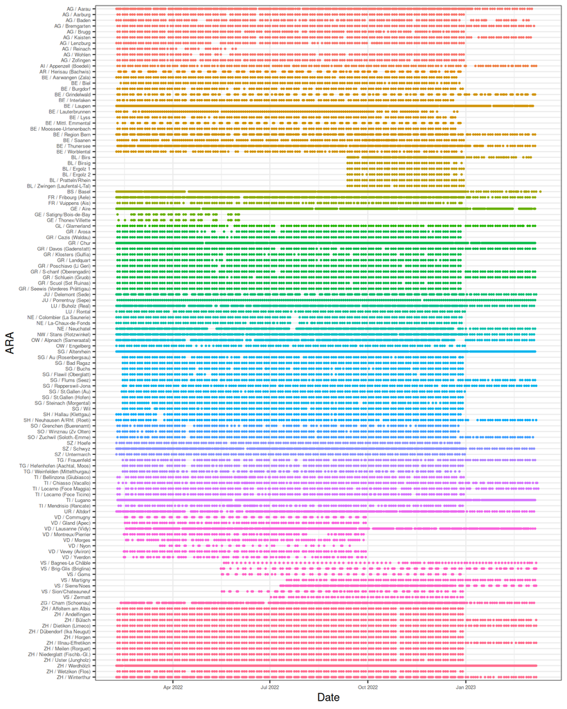

```r
mw_101_fig_missing(ww1)
```

**Figure 1.** Available measurements over time by ARA (grouped by canton).

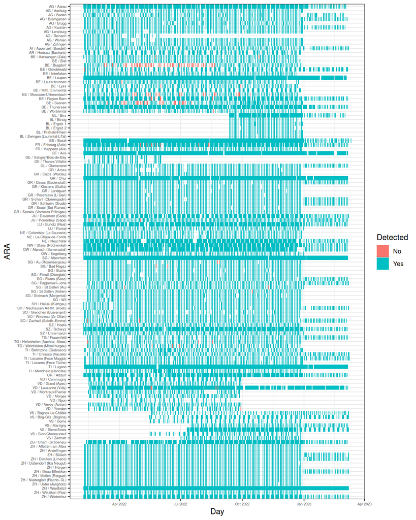

```r
mw_103_fig_detect(ww1,detect_limit=0)
```

**Figure 2.** SARS-CoV-2 detection in wastewater over time by ARA (limit=0).

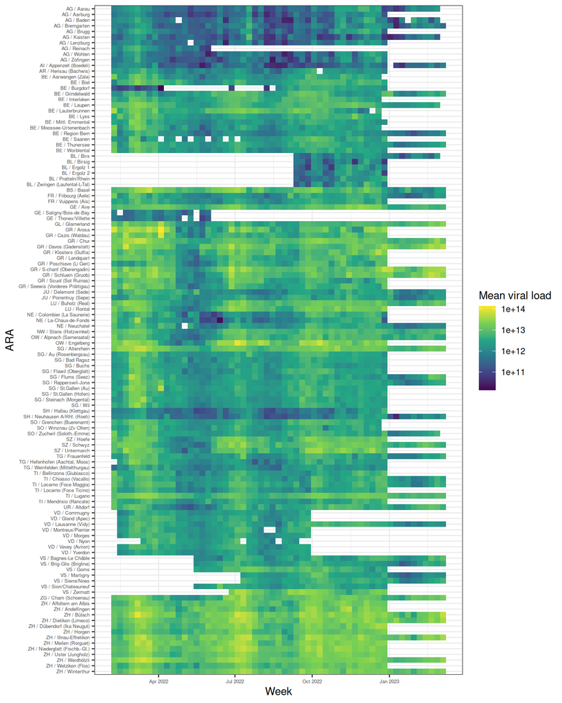

```r
mw_104_fig_vl(ww1,lower_limit=5000)
```

**Figure 3.** Weekly mean SARS-CoV-2 viral load in wastewater by ARA (removing one outlier below 5,000).